# An Introduction to Image Analysis with R

## How to use R for Image Analysis

## Using the EBImage package

### Let's install the EBImage package

```r
## try http:// if https:// URLs are not supported
source("https://bioconductor.org/biocLite.R")
biocLite("EBImage")
```

## Load the library

```r
library(EBImage)
```

## Goals for this Module

- Learn how to read and write images in and out of *R*
- Learn how images are represented in *R* and how to manipulate them
- Understand how to apply filters and transformations to images
- Apply these skills to microscopy images of cells to do segmentation and feature extraction
- Explore spatial distributions of the position of cells

## EBImage

### Image processing and analysis toolbox for *R*

- Reading and writing of image files
- Interactive image viewer
- Image manipulation, transformation and filtering
- Object detection and feature extraction

## Let's get started!

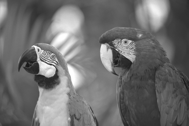

```r
library(EBImage)

f = system.file("images", "sample.png", package="EBImage")
img = readImage(f)

display(img)
```

## Reading and displaying images

### Reading images

Images can be read from local files or URLs.

```r
bioc = readImage("http://www.bioconductor.org/images/logo/jpg/bioconductor_logo_rgb.jpg")
display(bioc)
```

[output not shown]

|  | *EBImage* supports JPEG, PNG and TIFF file formats. For reading proprietary microscopy image data and metadata use *RBioFormats*. |
| --- | --- |

### Displaying images

- interactive JavaScript viewer
- *R*'s build-in plotting device

The default `display` method can be set by `options(EBImage.display)`.

```r
options(EBImage.display = "raster")
```

## Adding text labels

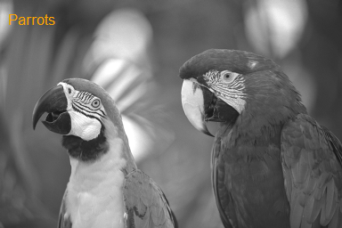

```r
display(img, method = "raster")
text(x = 20, y = 20, label = "Parrots", adj = c(0,1), col = "orange", cex = 2)
```

```r
filename = "parrots.jpg"
dev.print(jpeg, filename = filename , width = dim(img)[1], height = dim(img)[2])
```

```r
file.size(filename)
```

```
## [1] 33586
```

## Writing images

Supported file formats: JPEG, PNG and TIFF.

```r
writeImage(img, "sample.jpeg", quality = 85)

writeImage(img, "sample.tiff")
writeImage(img, "sample_compressed.tiff", compression = "deflate")

files = list.files(pattern = "sample*")
data.frame(row.names=files, size=file.size(files))
```

```
##                          size
## sample.jpeg             49688
## sample.tiff            393384
## sample_compressed.tiff 293788
```

## Image representation

Multi-dimensional pixel intensity arrays

- (x, y)
- (x, y, **z**) z-stack
- (x, y, **t**) time-lapse
- (x, y, **c**) channels
- (x, y, c, z, t, …)

[figure not shown]

## Image representation

```r
str(img)
```

```
## Formal class 'Image' [package "EBImage"] with 2 slots
##   ..@ .Data    : num [1:768, 1:512] 0.447 0.451 0.463 0.455 0.463 ...
##   ..@ colormode: int 0
```

```r
getClassDef("Image")
```

```
## Class "Image" [package "EBImage"]
##
## Slots:
##
## Name:      .Data colormode
## Class:     array   integer
##
## Extends:
## Class "array", from data part
## Class "structure", by class "array", distance 2
## Class "vector", by class "array", distance 3, with explicit coerce
```

```r
dim(img)
```

```
## [1] 768 512
```

## Image summary

```r
img
```

```
## Image
##   colorMode    : Grayscale
##   storage.mode : double
##   dim          : 768 512
##   frames.total : 1
##   frames.render: 1
##
## imageData(object)[1:5,1:6]
##           [,1]      [,2]      [,3]      [,4]      [,5]      [,6]
## [1,] 0.4470588 0.4627451 0.4784314 0.4980392 0.5137255 0.5294118
## [2,] 0.4509804 0.4627451 0.4784314 0.4823529 0.5058824 0.5215686
## [3,] 0.4627451 0.4666667 0.4823529 0.4980392 0.5137255 0.5137255
## [4,] 0.4549020 0.4666667 0.4862745 0.4980392 0.5176471 0.5411765
## [5,] 0.4627451 0.4627451 0.4823529 0.4980392 0.5137255 0.5411765
```

```r
imageData(img)[1:3, 1:6]
```

```
##           [,1]      [,2]      [,3]      [,4]      [,5]      [,6]
## [1,] 0.4470588 0.4627451 0.4784314 0.4980392 0.5137255 0.5294118
## [2,] 0.4509804 0.4627451 0.4784314 0.4823529 0.5058824 0.5215686
## [3,] 0.4627451 0.4666667 0.4823529 0.4980392 0.5137255 0.5137255
```

## Image histogram

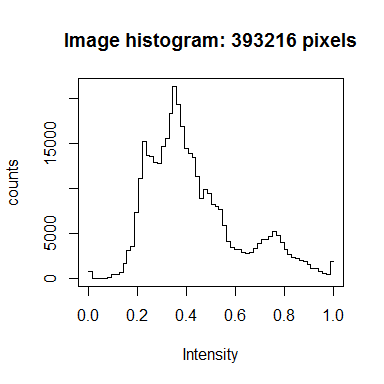

```r
hist(img)
```

```r
range(img)
```

```
## [1] 0 1
```

## Color images

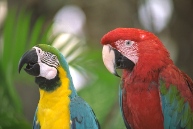

```r
f = system.file("images", "sample-color.png", package="EBImage")
imgcol = readImage(f)
display(imgcol)
```

```r
print(imgcol, short = TRUE)
```

```
## Image
##   colorMode    : Color
##   storage.mode : double
##   dim          : 768 512 3
##   frames.total : 3
##   frames.render: 1
```

## Image stacks

```r
nuc = readImage(system.file("images", "nuclei.tif", package="EBImage"))
print(nuc, short = TRUE)
```

```
## Image
##   colorMode    : Grayscale
##   storage.mode : double
##   dim          : 510 510 4
##   frames.total : 4
##   frames.render: 4
```

```r
display(nuc)
```

```
## Only the first frame of the image stack is displayed.
## To display all frames use 'all = TRUE'.
```

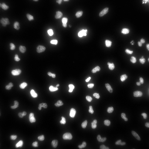

## Image stacks

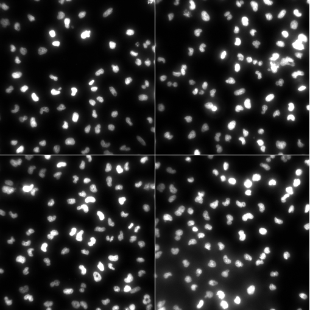

```r
display(nuc, method = "raster", all = TRUE)
```

## Manipulating images

Being numeric arrays, images can be conveniently manipulated by any of *R*'s arithmetic operators.

### Cropping

```r
img = img[366:749, 58:441]
```

### Inversion

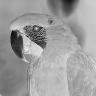

```r
img_neg = max(img) - img
display(img_neg)
```

## Manipulating images

### Brightness, contrast, and gamma correction

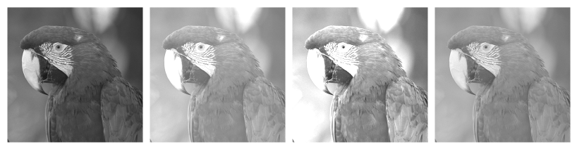

```r
img_comb = combine(
  img,
  img + 0.3,
  img * 2,
  img ^ 0.5
)

display( tile(img_comb, numberOfFrames(img_comb), lwd = 20, fg.col = "white") )
```

## Thresholding images

### Binary images

Images which contain only two sets of pixels, which represent the background and the foreground pixels.

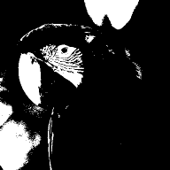

```r
img_thresh = img > .5
display(img_thresh)
```

## Tresholding images

### Binary images

Images which contain only two sets of pixels, which represent the background and the foreground pixels.

```r
img_thresh
```

```
## Image
##   colorMode    : Grayscale
##   storage.mode : logical
##   dim          : 384 384
##   frames.total : 1
##   frames.render: 1
##
## imageData(object)[1:5,1:6]
##       [,1]  [,2]  [,3]  [,4]  [,5]  [,6]
## [1,] FALSE FALSE FALSE FALSE FALSE FALSE
## [2,] FALSE FALSE FALSE FALSE FALSE FALSE
## [3,] FALSE FALSE FALSE FALSE FALSE FALSE
## [4,] FALSE FALSE FALSE FALSE FALSE FALSE
## [5,] FALSE FALSE FALSE FALSE FALSE FALSE
```

## Spatial transformations

### Translation

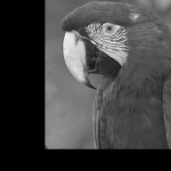

```r
img_translate = translate(img, v = c(100, -50))
display(img_translate)
```

## Spatial transformations

### Rotation

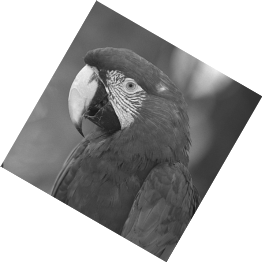

```r
img_rotate = rotate(img, angle = 30, bg.col = "white")
display(img_rotate)
```

## Spatial transformations

### Scaling

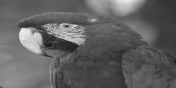

```r
img_resize = resize(img, w = 512, h = 256)
display(img_resize)
```

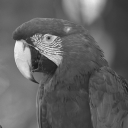

```r
img_resize = resize(img, 256)
display(img_resize)
```

## Spatial transformations

### Vertical and horizontal reflection

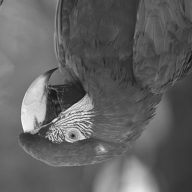

```r
display( flip(img) )
```

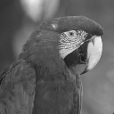

```r
display( flop(img) )
```

## Image transposition

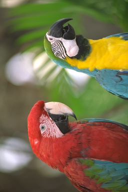

```r
imgcol_t = transpose(imgcol)
display(imgcol_t)
```